# GA4 Certification Assignment

Author

Raymond Marquez

# 1 **Module/Sub-module Completion**

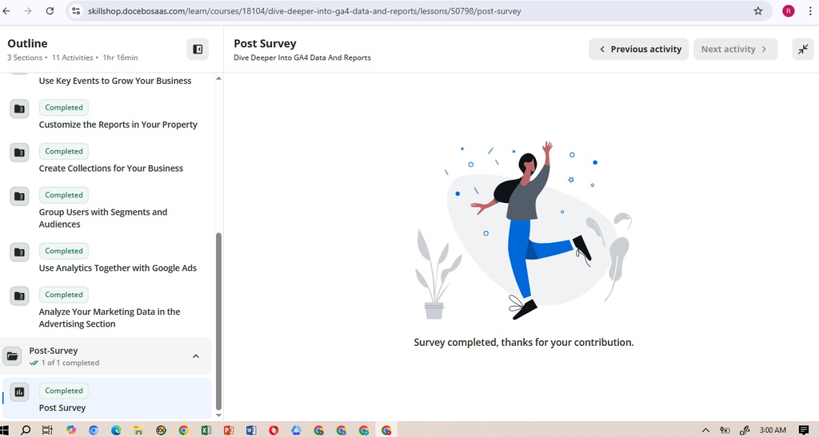

[figure not shown]

## 1.1 **Figure 1:** Exploration setup (show steps/segments)

[figure not shown]

[figure not shown]

## 1.2 **Figure 2:** Exploration results (show drop-offs, paths, or overlap)

[figure not shown]

[figure not shown]

# 2 **Short Answers**

## 2.1 What question were you trying to answer?

*I was trying to determine how users move through the conversion funnel from homepage view to purchase and where the biggest drop-offs occur. I also explored which pages users commonly visit first and how navigation behavior impacts conversions.*

## 2.2 What did you find?

- Out of **34,852 homepage views**, only **337 users (0.97%)** reached the Add to Cart stage, showing a very large early funnel drop-off.
- The homepage stage had the highest abandonment rate at **99.03%**, indicating low progression into product engagement.
- From Add to Cart to Add Payment Information, the completion rate improved to **37.09%**, showing stronger intent among users who reach this stage.
- Final purchases totaled **85 users**, meaning only about **0.2%** of initial homepage visitors completed the funnel.

## 2.3 What’s your next investigation step based on the results?

*Next, I would analyze landing page performance and traffic source segmentation to identify which channels or pages produce higher Add to Cart rates. I would also review device type or user behavior flow to determine where engagement drops sharply.*

## 2.4 What’s one action you would recommend for your CEP/client?

- Optimize homepage design with clearer calls-to-action and product visibility to reduce the 99% early abandonment rate.
- Implement A/B testing on homepage layouts or featured products to increase Add to Cart conversion.